## Introduction

### Course Information

### Multivriate Data

- “multi” means more than one
- Multivariate data: the data with on many variables

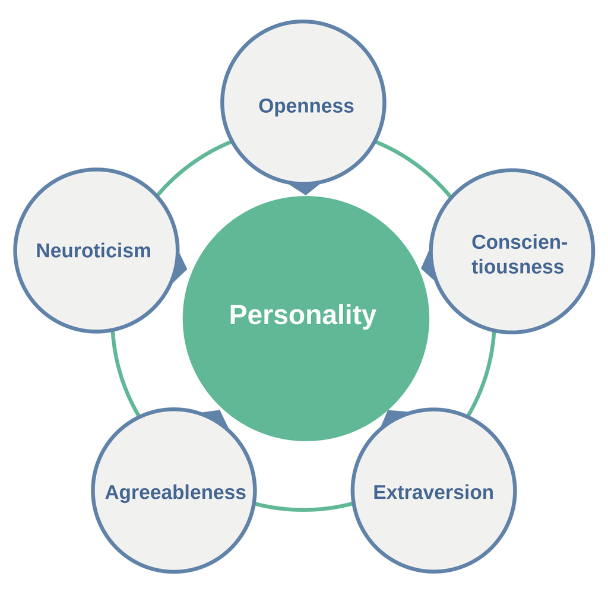

### More Examples of Multivariate Data

- A basketball player: points, rebounds, steals, assists, turnovers, free throws, fouls, etc
- A person’s well-being: social, economic, psychological, medical, physical, etc
- A person’s annual physical exam report

### What is Multivariate Analysis

- Statistical techniques used to analyze data with multiple variables
- It often analyzes the joint behavior of several variables simultaneously to identify patterns and relationships

### Learning Objectives

- Matrix algebra, distributions
- Visualization
- Inference about a mean vector or multiple mean vectors
- Multivariate analysis of variance (MANOVA)and multivariate regression
- Linear discriminant analysis (LDA)
- Principal component analysis (PCA)
- Cluster analysis
- Factor analysis

### Milestones in the history of multivariate analysis

## Special Matrices

### Vectors

- There are many ways to create a vector

```r
x=rep(0.3, 4)
x
```

```
## [1] 0.3 0.3 0.3 0.3
```

```r
x=seq(1, 4, by=0.2)
x
```

```
##  [1] 1.0 1.2 1.4 1.6 1.8 2.0 2.2 2.4 2.6 2.8 3.0 3.2 3.4 3.6 3.8 4.0
```

```r
c("a1", "a2", "a3")
```

```
## [1] "a1" "a2" "a3"
```

### Vectors

```r
x=c(0.4, 0.2, 0.5)
x
```

```
## [1] 0.4 0.2 0.5
```

```r
length(x)
```

```
## [1] 3
```

```r
dim(x)
```

[output not shown]

### A row or column of a matrix is also a vector

```r
x=rbind(c(0.4,0.2,0.5), rep(1,3))
dim(x)
```

```
## [1] 2 3
```

```r
x[1,]
```

```
## [1] 0.4 0.2 0.5
```

```r
x[,1]
```

```
## [1] 0.4 1.0
```

### Row or Column Vectors

- A vector (column vector) is a special matrix consisting of a single column of elements
- A row vector is a special matrix consisting of a single row of elements
- In this class, a vector means a column vector

### Row or Column Vectors

- In vector/matrix operations, it is helpful to define row or column vectors
- A row vector

```r
matrix(rep(0.5,3), 1, 3)
```

```
##      [,1] [,2] [,3]
## [1,]  0.5  0.5  0.5
```

```r
dim(matrix(rep(0.5,3), 1, 3))
```

```
## [1] 1 3
```

```r
#A neater way is to use the pipe "%>%"
matrix(rep(0.5,3), 1, 3) %>% dim
```

```
## [1] 1 3
```

### Row or Column Vectors

- A column vector

```r
x= matrix(rep(0.5,3), 3, 1)
dim(x)
```

```
## [1] 3 1
```

```r
# use pipe
x %>% dim
```

```
## [1] 3 1
```

### Transposes

- The transpose of a column vector is a row vector
- The transpose of a row vector is a column vector

```r
x= matrix(rep(0.5,3), 3, 1)
x
```

```
##      [,1]
## [1,]  0.5
## [2,]  0.5
## [3,]  0.5
```

```r
t(x)
```

```
##      [,1] [,2] [,3]
## [1,]  0.5  0.5  0.5
```

### Types of Special Matrices

- Identity matrix
- Diagonal matrix
- All-ones matrix
- Random matrix

### Indentity Matrix

```r
#diag(1, 2)
diag(5, 3)
```

```
##      [,1] [,2] [,3]
## [1,]    5    0    0
## [2,]    0    5    0
## [3,]    0    0    5
```

```r
diag(1, 2, 3)
```

```
##      [,1] [,2] [,3]
## [1,]    1    0    0
## [2,]    0    1    0
```

### Diagonal Matrix

```r
diag(1:3)
```

```
##      [,1] [,2] [,3]
## [1,]    1    0    0
## [2,]    0    2    0
## [3,]    0    0    3
```

```r
seq(1,2, by=0.5) %>% diag
```

```
##      [,1] [,2] [,3]
## [1,]    1  0.0    0
## [2,]    0  1.5    0
## [3,]    0  0.0    2
```

### All-ones

```r
matrix(1, 3, 2)
```

```
##      [,1] [,2]
## [1,]    1    1
## [2,]    1    1
## [3,]    1    1
```

### Common Matrix Operations

### Basic Tools

### Advanced Tools